# Resolución del 1er taller de análisis estadístico con R

Author

Daniel Fernández

Published

August 31, 2024

**Nota**

No podemos tratar de llegar a las respuestas con el análisis si antes no sabemos cuál es la pregunta de investigación.

**Instrucciones**

Contexto simulado con fines académicos

En enero de 2024, un grupo de investigadores se dio cuenta de que en la población de Perú la mortalidad por infarto se había duplicado en comparación con hace 10 años. Tras revisar la literatura, encontraron que una de las principales razones de este aumento era la hipertensión arterial, un factor de riesgo que incrementaba hasta cuatro veces la probabilidad de desarrollar estos eventos (RR: 4.0). Además, descubrieron que en Perú, la prevalencia de hipertensión había aumentado del 12% en 2010 al 25% en 2024, coincidiendo con el alza de casos de infartos.

Los investigadores sospechaban que, de las diferentes variables de exposición que podrían causar este incremento en los casos, la adición de sal extra a las comidas se había vuelto mucho más frecuente. Por ende, plantearon la hipótesis de que agregar sal se asociaba con un incremento en la prevalencia de hipertensión. Debido a la falta de recursos, los investigadores solo pudieron realizar una entrevista transversal en la que se abordaron múltiples características de los participantes, con la finalidad de evitar confusión en la relación que buscaban.

A continuación, se presenta la estructura del taller para que pueda ser desarrollado de forma individual y enviado por correo

**Fecha de entrega**

Antes de las 10:00 pm, del 18 de agosto

## Cargar paquetes :D

```r
library(tidyverse)
library(haven)
```

## 1. Estadística descriptiva

**a) Importar la base de datos**

Para importar utilizaremos el paquete de `haven` que contiene la función `read_dta` que nos ayudará a importar archivos de STATA.

```r
base <- haven::read_dta("base_simulada.dta")
```

**b) Seleccionamos variables a utilizar**

Podemos usar `view(base)` para ver que tenemos una enorme cantidad de datos.

```r
dim(base)
```

```
[1] 1086  231
```

Observamos que son 1086 observaciones y 231 variables, pero a nosotros solo nos interesan pocas variables, así que seleccionaremos solo las de nuestro interés.

```r
base2 <- base %>% select(edad, sexo, instruccion2, estado_civil2, riqueza, etnia,
                         region2, residencia,
                         sentado_horas2, actividad_fisica_ipaq, IMC, fumadoractual,
                         ldl_colesterolmg_dl, primera_medida_sistolica,
                         primera_medida_diastolica,
                         pa_elevada2, hipertension, dias_agrega_sal, ps_sodio)
```

**c) De ser necesario limpieza y creación de variables**

Algunas variables ya tienen etiquetas para sus categorias, estas fueron creadas en STATA. Para que R las reconozca utilizaremos los siguientes comandos:

```r
base3 <- base2 %>% mutate(sexo = as_factor(sexo),
                          instruccion2 = as_factor(instruccion2),
                          estado_civil2 = as_factor(estado_civil2),
                          riqueza = as_factor(riqueza),
                          etnia = as_factor(etnia),
                          region2 = as_factor(region2),
                          residencia = as_factor(residencia),
                         sentado_horas2 = as_factor(sentado_horas2),
                         actividad_fisica_ipaq = as_factor(actividad_fisica_ipaq),
                         fumadoractual = as_factor(fumadoractual),
                         pa_elevada2  = as_factor(pa_elevada2),
                         hipertension = as_factor(hipertension),
                         sentado_horas2 = as.numeric(sentado_horas2),
                         dias_agrega_sal = as_factor(dias_agrega_sal))
```

*ACTIVIDAD 1*: Crea las siguientes variables

- Obesidad a partir del IMC (obesidad = IMC >=30)
- Presión arterial media [(PAS + 2*PAD)/3]
- Si añade sal a las comidas a partir de “*dias_agrega_sal” (*Añade_sal, etiqueta como”Sí” si los valores son diferentes de 0 días, o como “No” si es igual a 0 días como, ojo con valor de 99 que indica que no hay información)

```r
# Crear la columna Obesidad a partir del IMC (obesidad = IMC >=30)
base3 <- base3 %>%   mutate(obesidad = case_when(
    IMC >= 30 ~ "Sí",
    TRUE ~ "No"  ),

    IMC = NULL,

    PAM = (primera_medida_sistolica + 2 * primera_medida_diastolica) / 3,

    dias_agrega_sal = case_when(dias_agrega_sal  == 99 ~ NA_character_,
                                TRUE ~ dias_agrega_sal),
    Añade_sal = case_when(
            dias_agrega_sal  != "0"  ~ "Sí",
            dias_agrega_sal   == "0" ~ "No"))
```

*ACTIVIDAD 2*: Filtra la base de datos para que tengas una base sin datos perdidos y anota el numero de observaciones antes y despues de eliminar los datos perdidos

```r
# Número de observaciones antes de eliminar datos perdidos
observaciones_antes <- nrow(base3)
dim(base3)
```

```
[1] 1086   21
```

```r
# Filtrar la base para eliminar  datos perdidos

base3 <- na.omit(base3)
dim(base3)
```

```
[1] 275  21
```

```r
# Número de observaciones después de eliminar datos perdidos
observaciones_despues <- nrow(base3)
dim(base3)
```

```
[1] 275  21
```

```r
# Mostrar el número de observaciones antes y después
observaciones_antes
```

```
[1] 1086
```

```r
observaciones_despues
```

```
[1] 275
```

Ahora si estamos listos para empezar con el análisis.

*ACTIVIDAD 2*: Crea una tabla que presente las caracteristicas descriptivas de la muestra evaluada, no es necesario cambiar las etiquetas

OJO: evaluar si debes presentar media y desviación estandar o mediana y p25-p75

```r
#Edad

#Evaluar el tamaño  :275 ,  distribucion no normal/ uso mediana y p25-p75
sum(complete.cases(base3$edad))
```

```
[1] 275
```

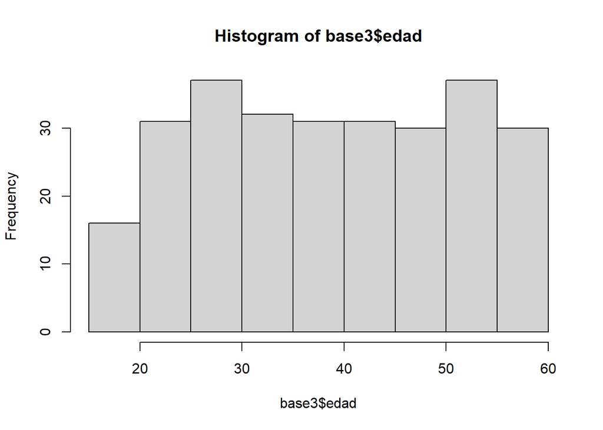

```r
hist(base3$edad)
```

```r
shapiro.test(base3$edad)
```

```
    Shapiro-Wilk normality test

data:  base3$edad
W = 0.94689, p-value = 1.996e-08
```

```r
skimr::skim(base3)
```

Data summary

| Name | base3 |
| --- | --- |
| Number of rows | 275 |
| Number of columns | 21 |
| _______________________ |  |
| Column type frequency: |  |
| character | 3 |
| factor | 11 |
| numeric | 7 |
| ________________________ |  |
| Group variables | None |

**Variable type: character**

| skim_variable | n_missing | complete_rate | min | max | empty | n_unique | whitespace |
| --- | --- | --- | --- | --- | --- | --- | --- |
| dias_agrega_sal | 0 | 1 | 1 | 1 | 0 | 8 | 0 |
| obesidad | 0 | 1 | 2 | 2 | 0 | 2 | 0 |
| Añade_sal | 0 | 1 | 2 | 2 | 0 | 2 | 0 |

**Variable type: factor**

| skim_variable | n_missing | complete_rate | ordered | n_unique | top_counts |
| --- | --- | --- | --- | --- | --- |
| sexo | 0 | 1 | FALSE | 2 | Fem: 155, Mas: 120 |
| instruccion2 | 0 | 1 | FALSE | 3 | Sec: 98, Sup: 96, Pri: 81 |
| estado_civil2 | 0 | 1 | FALSE | 2 | Con: 170, Sin: 105 |
| riqueza | 0 | 1 | FALSE | 3 | No_: 222, Pob: 39, Pob: 14 |
| etnia | 0 | 1 | FALSE | 3 | Mes: 149, Otr: 81, Que: 45 |
| region2 | 0 | 1 | FALSE | 4 | Lim: 87, Sie: 72, Cos: 66, Sel: 50 |
| residencia | 0 | 1 | FALSE | 2 | Urb: 161, Rur: 114 |
| actividad_fisica_ipaq | 0 | 1 | FALSE | 3 | Alt: 117, Mod: 94, Baj: 64 |
| fumadoractual | 0 | 1 | FALSE | 2 | No_: 244, Fum: 31 |
| pa_elevada2 | 0 | 1 | FALSE | 2 | Nor: 214, Ele: 61 |
| hipertension | 0 | 1 | FALSE | 2 | No: 258, Sí(: 17 |

**Variable type: numeric**

| skim_variable | n_missing | complete_rate | mean | sd | p0 | p25 | p50 | p75 | p100 | hist |
| --- | --- | --- | --- | --- | --- | --- | --- | --- | --- | --- |
| edad | 0 | 1 | 39.09 | 12.29 | 19.00 | 28.00 | 39.00 | 50.00 | 59.00 | ▇▇▆▆▇ |
| sentado_horas2 | 0 | 1 | 57.28 | 34.81 | 1.00 | 32.00 | 51.00 | 83.50 | 133.00 | ▆▇▅▅▃ |
| ldl_colesterolmg_dl | 0 | 1 | 113.37 | 38.99 | 22.00 | 86.00 | 112.00 | 137.50 | 292.00 | ▃▇▅▁▁ |
| primera_medida_sistolica | 0 | 1 | 109.93 | 14.62 | 80.00 | 101.00 | 109.00 | 118.00 | 203.00 | ▅▇▁▁▁ |
| primera_medida_diastolica | 0 | 1 | 72.29 | 9.18 | 50.00 | 65.50 | 72.00 | 77.50 | 117.00 | ▂▇▃▁▁ |
| ps_sodio | 0 | 1 | 367.33 | 295.87 | 1.11 | 146.28 | 303.51 | 519.38 | 1794.34 | ▇▃▁▁▁ |
| PAM | 0 | 1 | 84.84 | 10.22 | 61.67 | 78.33 | 84.33 | 90.67 | 145.67 | ▃▇▂▁▁ |

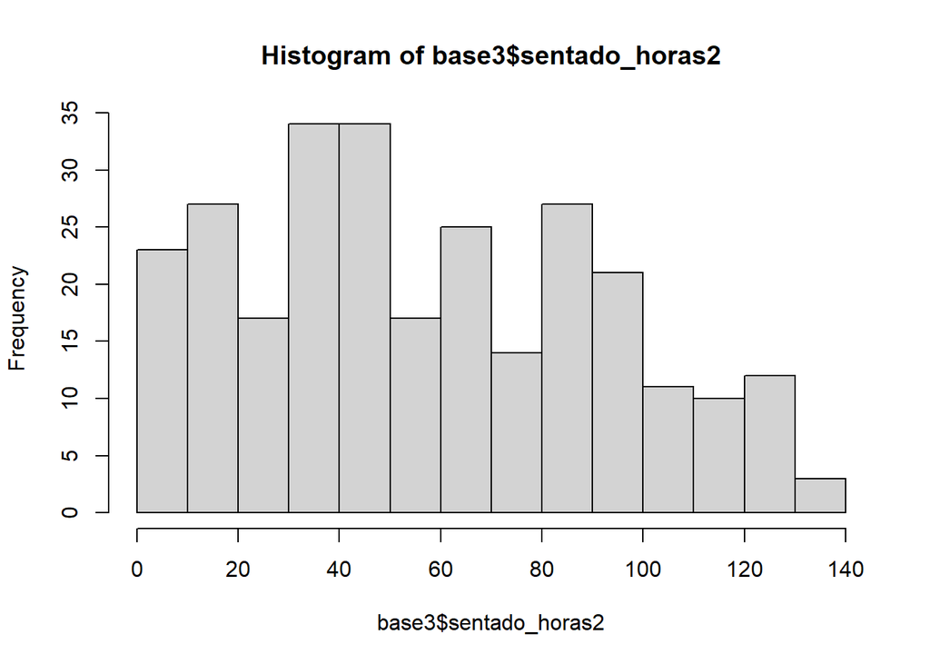

```r
#sentado_horas2 distribucion no normal
hist(base3$sentado_horas2)
```

```r
shapiro.test(base3$sentado_horas2)
```

```
    Shapiro-Wilk normality test

data:  base3$sentado_horas2
W = 0.96275, p-value = 1.565e-06
```

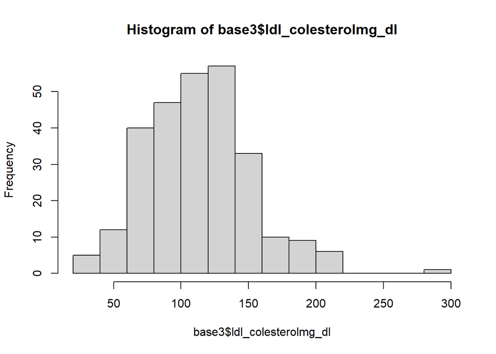

```r
#ldl_colesterolmg_dl distribucion no normal

hist(base3$ldl_colesterolmg_dl)
```

```r
shapiro.test(base3$ldl_colesterolmg_dl)
```

```
    Shapiro-Wilk normality test

data:  base3$ldl_colesterolmg_dl
W = 0.98163, p-value = 0.001311
```

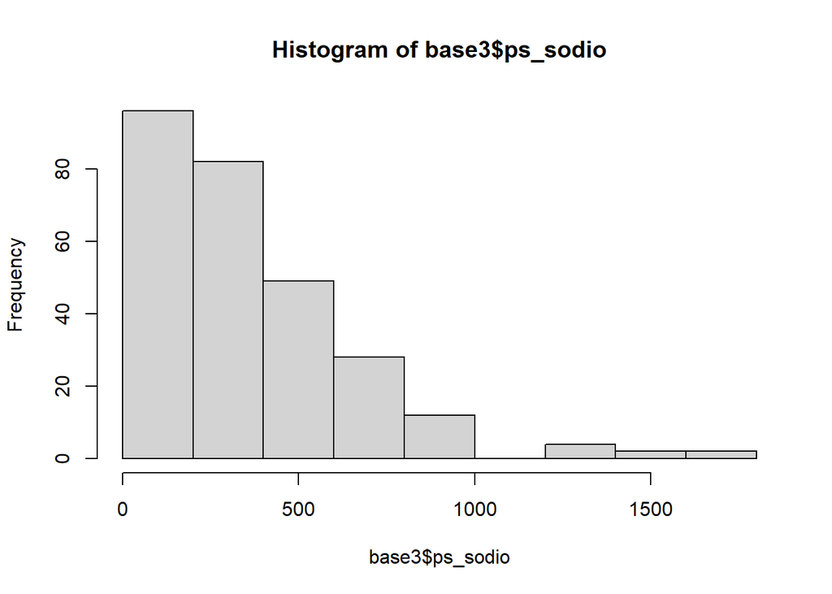

```r
#ps_sodio distribucion no normal

hist(base3$ps_sodio)
```

```r
shapiro.test(base3$ps_sodio)
```

```
    Shapiro-Wilk normality test

data:  base3$ps_sodio
W = 0.85934, p-value = 3.996e-15
```

Creamos la tabla!!!!

Cambiar para que se presente un decimal para % y para medidas de tendencia central y dispersión

```r
library(gtsummary)
set_gtsummary_theme(theme_gtsummary_compact())

# theme to round percentages to one decimal place
set_gtsummary_theme(list(`tbl_summary-fn:percent_fun` = function(x) sprintf("%.1f", x * 100)))

# formato de digitos
pacman::p_load(magrittr, purrr)
style_percent_1digits <- purrr::partial(gtsummary::style_percent, digits = 1)
style_number_2digits <- purrr::partial(gtsummary::style_number, digits = 2)

tbl_summary(base3)
```

Características de la muestra

| **Characteristic** | **N = 275**<sup>1</sup> |
| --- | --- |
| edad | 39 (28, 50) |
| sexo |  |
| Femenino | 155 (56.4%) |
| Masculino | 120 (43.6%) |
| RECODE of max_nivel_alcanzado |  |
| Superior | 96 (34.9%) |
| Secundario | 98 (35.6%) |
| Primario_o_menor | 81 (29.5%) |
| RECODE of estado_civil |  |
| Sin_pareja | 105 (38.2%) |
| Con_pareja | 170 (61.8%) |
| RECODE of pobreza (pobreza) |  |
| No_pobre | 222 (80.7%) |
| Pobre_no_extremo | 39 (14.2%) |
| Pobre_extremo | 14 (5.1%) |
| RECODE of p558c (por sus antepasados y de acuerdo a sus costumbres, ¿ud. se cons |  |
| Mestizo | 149 (54.2%) |
| Quechua | 45 (16.4%) |
| Otras_etnias | 81 (29.5%) |
| RECODE of region (dominio geográfico) |  |
| Lima | 87 (31.6%) |
| Costa | 66 (24.0%) |
| Sierra | 72 (26.2%) |
| Selva | 50 (18.2%) |
| RECODE of dominio_rural |  |
| Urbano | 161 (58.5%) |
| Rural | 114 (41.5%) |
| sentado_horas2 | 51 (32, 84) |
| actividad_fisica_ipaq |  |
| Alto | 117 (42.5%) |
| Bajo | 64 (23.3%) |
| Moderado | 94 (34.2%) |
| fumadoractual |  |
| No_fuma | 244 (88.7%) |
| Fuma | 31 (11.3%) |
| ldl_colesterolmg_dl | 112 (86, 138) |
| primera_medida_sistolica | 109 (101, 118) |
| primera_medida_diastolica | 72 (66, 78) |
| pa_elevada2 |  |
| Normal | 214 (77.8%) |
| Elevado(>=130/80) | 61 (22.2%) |
| hipertension |  |
| No | 258 (93.8%) |
| Sí(>=140/90) | 17 (6.2%) |
| dias_agrega_sal |  |
| 0 | 233 (84.7%) |
| 1 | 17 (6.2%) |
| 2 | 9 (3.3%) |
| 3 | 7 (2.5%) |
| 4 | 1 (0.4%) |
| 5 | 3 (1.1%) |
| 6 | 1 (0.4%) |
| 7 | 4 (1.5%) |
| ps_sodio | 304 (146, 519) |
| obesidad |  |
| No | 208 (75.6%) |
| Sí | 67 (24.4%) |
| PAM | 84 (78, 91) |
| Añade_sal |  |
| No | 233 (84.7%) |
| Sí | 42 (15.3%) |

<sup>1</sup> Median (IQR); n (%)

Pasemos por alto que la prevalencia de hipertensión no se acerca a la prevalencia que se reporta para la población peruana y trabajemos con la variable “**pa_elevada2**”

## 2. Estadística inferencial - pruebas de hipótesis

**Recuerda**

**Hipótesis:** Añadir sal a las comidas se asocia con mayor frecuencia de presión arterial elevada en la población peruana.

*ACTIVIDAD 3*: Crea una tabla bivariada en función del desenlace “presión arterial elevada” y presenta los valores p de las pruebas de hipótesis correspondientes (indicar que prueba se utilizó para cada variable.

```r
# Menos del 20% de las celdas tiene frecuencias menores de 5, se usa Chicuadrado
chi2<- chisq.test(base3$Añade_sal , base3$pa_elevada2)
chi2$expected
```

```
               base3$pa_elevada2
base3$Añade_sal    Normal Elevado(>=130/80)
             No 181.31636         51.683636
             Sí  32.68364          9.316364
```

```r
#valor p es igual a 1 , no hay diferencia estadisticamente significativa entre añadir sal a las comidas y la frecuencia de preseion arterial elevada en la poblacion peruana
tbl_summary(base3, by = pa_elevada2,
            missing = "no",
            percent = "row")%>%
  add_p(pvalue_fun = ~ style_pvalue(.x, digits = 3))
```

| **Characteristic** | **Normal**, N = 214<sup>1</sup> | **Elevado(>=130/80)**, N = 61<sup>1</sup> | **p-value**<sup>2</sup> |
| --- | --- | --- | --- |
| edad | 36 (27, 48) | 47 (37, 55) | <0.001 |
| sexo |  |  | 0.911 |
| Femenino | 121 (78.1%) | 34 (21.9%) |  |
| Masculino | 93 (77.5%) | 27 (22.5%) |  |
| RECODE of max_nivel_alcanzado |  |  | 0.523 |
| Superior | 73 (76.0%) | 23 (24.0%) |  |
| Secundario | 80 (81.6%) | 18 (18.4%) |  |
| Primario_o_menor | 61 (75.3%) | 20 (24.7%) |  |
| RECODE of estado_civil |  |  | 0.114 |
| Sin_pareja | 87 (82.9%) | 18 (17.1%) |  |
| Con_pareja | 127 (74.7%) | 43 (25.3%) |  |
| RECODE of pobreza (pobreza) |  |  | 0.648 |
| No_pobre | 172 (77.5%) | 50 (22.5%) |  |
| Pobre_no_extremo | 32 (82.1%) | 7 (17.9%) |  |
| Pobre_extremo | 10 (71.4%) | 4 (28.6%) |  |
| RECODE of p558c (por sus antepasados y de acuerdo a sus costumbres, ¿ud. se cons |  |  | 0.400 |
| Mestizo | 118 (79.2%) | 31 (20.8%) |  |
| Quechua | 37 (82.2%) | 8 (17.8%) |  |
| Otras_etnias | 59 (72.8%) | 22 (27.2%) |  |
| RECODE of region (dominio geográfico) |  |  | 0.125 |
| Lima | 69 (79.3%) | 18 (20.7%) |  |
| Costa | 48 (72.7%) | 18 (27.3%) |  |
| Sierra | 62 (86.1%) | 10 (13.9%) |  |
| Selva | 35 (70.0%) | 15 (30.0%) |  |
| RECODE of dominio_rural |  |  | 0.704 |
| Urbano | 124 (77.0%) | 37 (23.0%) |  |
| Rural | 90 (78.9%) | 24 (21.1%) |  |
| sentado_horas2 | 48 (32, 82) | 54 (32, 87) | 0.541 |
| actividad_fisica_ipaq |  |  | 0.682 |
| Alto | 89 (76.1%) | 28 (23.9%) |  |
| Bajo | 49 (76.6%) | 15 (23.4%) |  |
| Moderado | 76 (80.9%) | 18 (19.1%) |  |
| fumadoractual |  |  | 0.688 |
| No_fuma | 189 (77.5%) | 55 (22.5%) |  |
| Fuma | 25 (80.6%) | 6 (19.4%) |  |
| ldl_colesterolmg_dl | 112 (88, 138) | 114 (81, 134) | 0.497 |
| primera_medida_sistolica | 106 (98, 114) | 123 (115, 130) | <0.001 |
| primera_medida_diastolica | 69 (64, 74) | 83 (80, 88) | <0.001 |
| hipertension |  |  | <0.001 |
| No | 214 (82.9%) | 44 (17.1%) |  |
| Sí(>=140/90) | 0 (0.0%) | 17 (100.0%) |  |
| dias_agrega_sal |  |  | 0.800 |
| 0 | 181 (77.7%) | 52 (22.3%) |  |
| 1 | 12 (70.6%) | 5 (29.4%) |  |
| 2 | 7 (77.8%) | 2 (22.2%) |  |
| 3 | 7 (100.0%) | 0 (0.0%) |  |
| 4 | 1 (100.0%) | 0 (0.0%) |  |
| 5 | 2 (66.7%) | 1 (33.3%) |  |
| 6 | 1 (100.0%) | 0 (0.0%) |  |
| 7 | 3 (75.0%) | 1 (25.0%) |  |
| ps_sodio | 296 (154, 520) | 315 (129, 511) | 0.788 |
| obesidad |  |  | <0.001 |
| No | 174 (83.7%) | 34 (16.3%) |  |
| Sí | 40 (59.7%) | 27 (40.3%) |  |
| PAM | 82 (76, 86) | 95 (92, 101) | <0.001 |
| Añade_sal |  |  | 0.898 |
| No | 181 (77.7%) | 52 (22.3%) |  |
| Sí | 33 (78.6%) | 9 (21.4%) |  |

<sup>1</sup> Median (IQR); n (%)  
<sup>2</sup> Wilcoxon rank sum test; Pearson’s Chi-squared test; Fisher’s exact test

*ACTIVIDAD 4*: Crea una tabla bivariada en función de la variable de exposición creada “Añadir sal a las comidas” (Añade_sal) y presenta los valores p de las pruebas de hipótesis correspondientes (indicar que prueba se utilizó para cada variable.

```r
tbl_summary(base3, by = Añade_sal,
            missing = "no",
            percent = "row")%>%
  add_p(pvalue_fun = ~ style_pvalue(.x, digits = 3))
```

| **Characteristic** | **No**, N = 233<sup>1</sup> | **Sí**, N = 42<sup>1</sup> | **p-value**<sup>2</sup> |
| --- | --- | --- | --- |
| edad | 39 (29, 50) | 35 (27, 49) | 0.208 |
| sexo |  |  | 0.003 |
| Femenino | 140 (90.3%) | 15 (9.7%) |  |
| Masculino | 93 (77.5%) | 27 (22.5%) |  |
| RECODE of max_nivel_alcanzado |  |  | 0.989 |
| Superior | 81 (84.4%) | 15 (15.6%) |  |
| Secundario | 83 (84.7%) | 15 (15.3%) |  |
| Primario_o_menor | 69 (85.2%) | 12 (14.8%) |  |
| RECODE of estado_civil |  |  | 0.307 |
| Sin_pareja | 86 (81.9%) | 19 (18.1%) |  |
| Con_pareja | 147 (86.5%) | 23 (13.5%) |  |
| RECODE of pobreza (pobreza) |  |  | 0.100 |
| No_pobre | 191 (86.0%) | 31 (14.0%) |  |
| Pobre_no_extremo | 33 (84.6%) | 6 (15.4%) |  |
| Pobre_extremo | 9 (64.3%) | 5 (35.7%) |  |
| RECODE of p558c (por sus antepasados y de acuerdo a sus costumbres, ¿ud. se cons |  |  | 0.164 |
| Mestizo | 128 (85.9%) | 21 (14.1%) |  |
| Quechua | 34 (75.6%) | 11 (24.4%) |  |
| Otras_etnias | 71 (87.7%) | 10 (12.3%) |  |
| RECODE of region (dominio geográfico) |  |  | 0.025 |
| Lima | 79 (90.8%) | 8 (9.2%) |  |
| Costa | 58 (87.9%) | 8 (12.1%) |  |
| Sierra | 60 (83.3%) | 12 (16.7%) |  |
| Selva | 36 (72.0%) | 14 (28.0%) |  |
| RECODE of dominio_rural |  |  | 0.841 |
| Urbano | 137 (85.1%) | 24 (14.9%) |  |
| Rural | 96 (84.2%) | 18 (15.8%) |  |
| sentado_horas2 | 53 (32, 81) | 48 (33, 93) | 0.739 |
| actividad_fisica_ipaq |  |  | 0.018 |
| Alto | 91 (77.8%) | 26 (22.2%) |  |
| Bajo | 59 (92.2%) | 5 (7.8%) |  |
| Moderado | 83 (88.3%) | 11 (11.7%) |  |
| fumadoractual |  |  | 0.108 |
| No_fuma | 210 (86.1%) | 34 (13.9%) |  |
| Fuma | 23 (74.2%) | 8 (25.8%) |  |
| ldl_colesterolmg_dl | 112 (85, 136) | 107 (90, 140) | 0.892 |
| primera_medida_sistolica | 110 (101, 118) | 109 (98, 117) | 0.893 |
| primera_medida_diastolica | 72 (66, 77) | 73 (63, 78) | 0.858 |
| pa_elevada2 |  |  | 0.898 |
| Normal | 181 (84.6%) | 33 (15.4%) |  |
| Elevado(>=130/80) | 52 (85.2%) | 9 (14.8%) |  |
| hipertension |  |  | 0.484 |
| No | 217 (84.1%) | 41 (15.9%) |  |
| Sí(>=140/90) | 16 (94.1%) | 1 (5.9%) |  |
| dias_agrega_sal |  |  | <0.001 |
| 0 | 233 (100.0%) | 0 (0.0%) |  |
| 1 | 0 (0.0%) | 17 (100.0%) |  |
| 2 | 0 (0.0%) | 9 (100.0%) |  |
| 3 | 0 (0.0%) | 7 (100.0%) |  |
| 4 | 0 (0.0%) | 1 (100.0%) |  |
| 5 | 0 (0.0%) | 3 (100.0%) |  |
| 6 | 0 (0.0%) | 1 (100.0%) |  |
| 7 | 0 (0.0%) | 4 (100.0%) |  |
| ps_sodio | 301 (157, 525) | 306 (105, 460) | 0.364 |
| obesidad |  |  | 0.383 |
| No | 174 (83.7%) | 34 (16.3%) |  |
| Sí | 59 (88.1%) | 8 (11.9%) |  |
| PAM | 84 (78, 90) | 85 (78, 91) | 0.955 |

<sup>1</sup> Median (IQR); n (%)  
<sup>2</sup> Wilcoxon rank sum test; Pearson’s Chi-squared test; Fisher’s exact test

```r
# para las variables categoricas se usa  chi 2
# edad prueba de Mann Whitney
```

## 3. Estadística inferencial - regresiones

*ACTIVIDAD 5*: Crea una tabla de regresión lineal simple y ajustada para la relación de agregar sal (variable de exposición dicotómica) y el desenlace “presión arterial media” (PAM)

Considera en el modelo las variables que creas que son confusoras en la relación causal que estas intentando demostrar

Los decimales deben ser 2 para los coeficientes y 3 para el valor p

```r
# Instalar y cargar el paquete performance
#install.packages("performance")
library(performance)
library(dplyr)
library(broom)
# Primero : Regresion lineal simple
model_simple <- lm(PAM~Añade_sal, data = base3)

tbl_regression(model_simple,
               pvalue_fun = function(x) style_pvalue(x, digits = 3))
```

| **Characteristic** | **Beta** | **95% CI**<sup>1</sup> | **p-value** |
| --- | --- | --- | --- |
| Añade_sal |  |  |  |
| No | — | — |  |
| Sí | -0.28 | -3.7, 3.1 | 0.873 |

<sup>1</sup> CI = Confidence Interval

```r
# Segundo: Regresion lineal ajustada(edad, obesidad)

# podrian añadir mas variables de acuerdo a su DAG no hay modelos incorrectos :D

model_ajustado <- lm(PAM ~ Añade_sal + edad + obesidad + ps_sodio, data = base3)


tbl_regression(model_ajustado,
               pvalue_fun = function(x) style_pvalue(x, digits = 3))
```

| **Characteristic** | **Beta** | **95% CI**<sup>1</sup> | **p-value** |
| --- | --- | --- | --- |
| Añade_sal |  |  |  |
| No | — | — |  |
| Sí | 0.60 | -2.6, 3.8 | 0.711 |
| edad | 0.21 | 0.12, 0.31 | <0.001 |
| obesidad |  |  |  |
| No | — | — |  |
| Sí | 5.2 | 2.5, 7.9 | <0.001 |
| ps_sodio | 0.00 | 0.00, 0.00 | 0.824 |

<sup>1</sup> CI = Confidence Interval

Antes de interpretar los coeficientes, evalúa los supuestos solo para la variable de exposición

```r
# Evaluación de los Supuestos del Modelo

#Paso 1: Crear el Modelo Simple
model_simple
```

```
Call:
lm(formula = PAM ~ Añade_sal, data = base3)

Coefficients:
(Intercept)  Añade_salSí
    84.8784      -0.2752
```

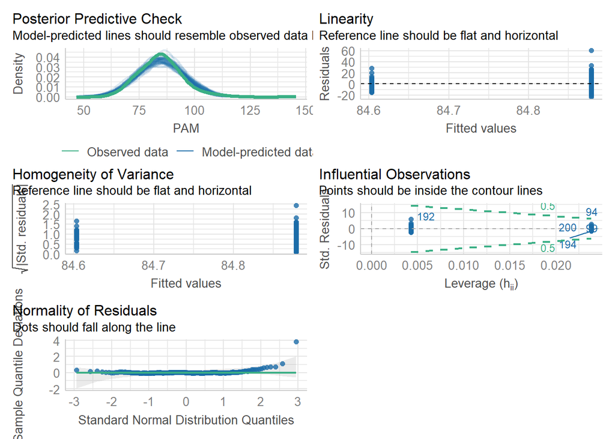

```r
#Paso 2: Evaluación de los Supuestos
#1  Linealidad: por defecto si cumple para variables independientes categoricas
library(performance)
library(lmtest)
check_model(model_simple)
```

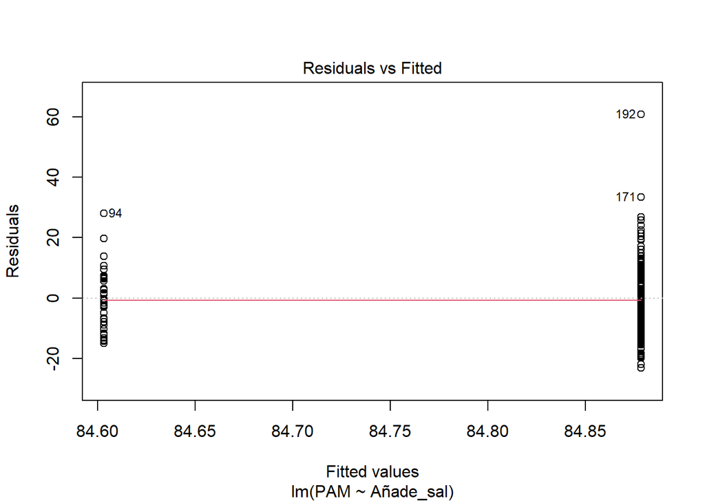

```r
# opcion 2
plot(model_simple, which = 1)
```

```r
#2 Independencia -- si  cumple
# Prueba de Durbin-Watson --> es opcional
dwtest(model_simple)
```

```
    Durbin-Watson test

data:  model_simple
DW = 2.0073, p-value = 0.5215
alternative hypothesis: true autocorrelation is greater than 0
```

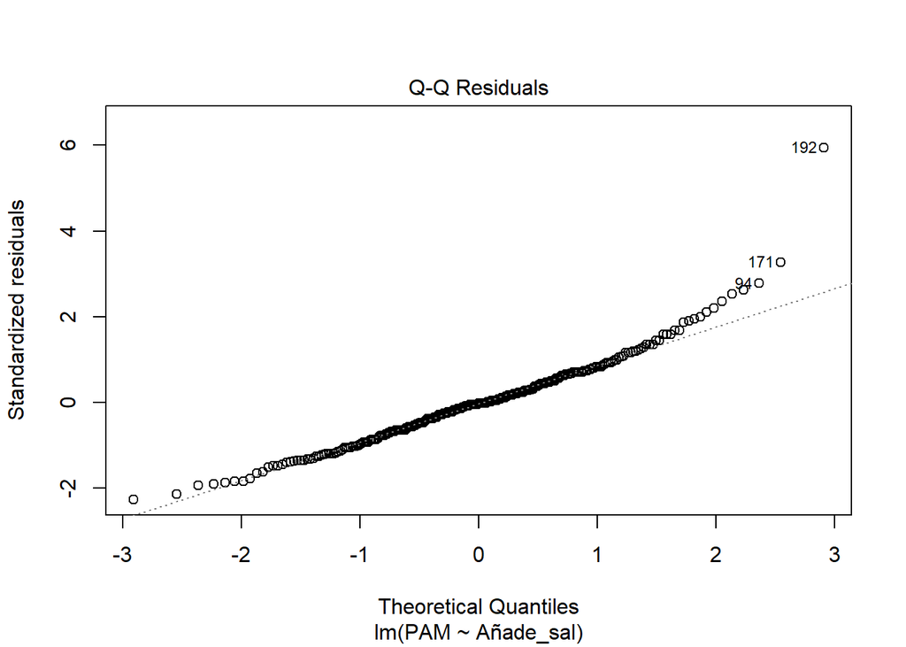

```r
#3 normalidad   -->  No cumple, deberia de realizarse bootstrap (no lo haremos porque estamos comenzando)
plot(model_simple, which = 2)
```

```r
check_normality(model_simple)
shapiro.test(resid(model_simple))
```

```
    Shapiro-Wilk normality test

data:  resid(model_simple)
W = 0.95257, p-value = 8.638e-08
```

```r
# Homocedasticidad-- si  cumple
check_homogeneity(model_simple)
```

```
OK: There is not clear evidence for different variances across groups (Bartlett Test, p = 0.475).
```

```r
# Prueba de Cook-Weisberg (Breusch-Pagan)
 lmtest::bptest(model_simple)
```

```
    studentized Breusch-Pagan test

data:  model_simple
BP = 0.19104, df = 1, p-value = 0.6621
```

```r
library(gtsummary)
# Si cumple todo recien podremos interpreta los resultados
tbl_regression(model_simple,
               pvalue_fun = function(x) style_pvalue(x, digits = 3))
```

| **Characteristic** | **Beta** | **95% CI**<sup>1</sup> | **p-value** |
| --- | --- | --- | --- |
| Añade_sal |  |  |  |
| No | — | — |  |
| Sí | -0.28 | -3.7, 3.1 | 0.873 |

<sup>1</sup> CI = Confidence Interval

```r
#Interpretacion:
#En la población de estudio, la PAM es 0.28 unidades menor en el grupo que añade sal a las comidas en comparación con el grupo que no añade sal. Esta diferencia no es estadísticamente significativa.
```

*ACTIVIDAD 6*: Crea una tabla de regresión de poisson con varianza robusta cruda y ajustada para la relación de agregar sal (variable de exposición dicotómica) y el desenlace dicotómico “presión arterial elevada” (pa_elevada2)

Considera en el modelo las variables que creas que son confusoras en la relación causal que estas intentando demostrar